# Hake data sources for CEATTLE

Sophia Wassermann

4 May 2022

## Summary

CEATTLE - Climate-Enhanced, Age-based model with Temperature-specific Trophic Linkages and Energetics - is a multi-species, age-structured assessment model that has been used for groundfish in the Bering Sea and Gulf of Alaska. This project seeks to apply CEATTLE to Pacific hake in the California Current Ecosystem. Pacific hake are an important fishery on the US West Coast ($60 million in 2017), and are one of the most abundant predators. This implementation of CEATTLE focuses on hake cannibalism.

## Data sources

CEATTLE is implemented through the [RCeattle](https://github.com/grantdadams/Rceattle) package, a wrapper for the model built in Template Model Builder (TMB). The model incorporates data from multiple sources: primarily the [hake stock assessment](https://github.com/pacific-hake/hake-assessment) conducted by the Northwest Fisheries Science Center (NWFSC), with the climate and trophic linkeages integrated through temperature-specific bioenergetics and predation (diet) data.

### Hake assessment

The data inputs into CEATTLE include survey and fishery catch data, length and age composition, and empirical weight-at-age. These data are from the [hake assessment](https://github.com/pacific-hake/hake-assessment).

### Temperature

Temperature data are available from the acoustic survey for hake for 13 years between 1995-2019. The temperature is reported for 100m, or bottom temp if the bottom was <100m, and were collected with a variety of instruments.

Temperature data are used in two ways in CEATTLE: 1) a mean temperature per year is provided, 2) optimal and maximum temperatures for each species are included in the bioenergetics calculations. With no clear values in the literature to use for Pacific hake, the temperature where hake occurred during the survey can be used as an estimate. The temperature across the survey had been kriged and used to create a spatial grid across the survey area. The temperature from this grid was then assigned to hake biomass estimates ([Malick et al. 2020](https://www.int-res.com/abstracts/meps/v639/p185-197/)) and filtered for when hake were present (biomass > 0).

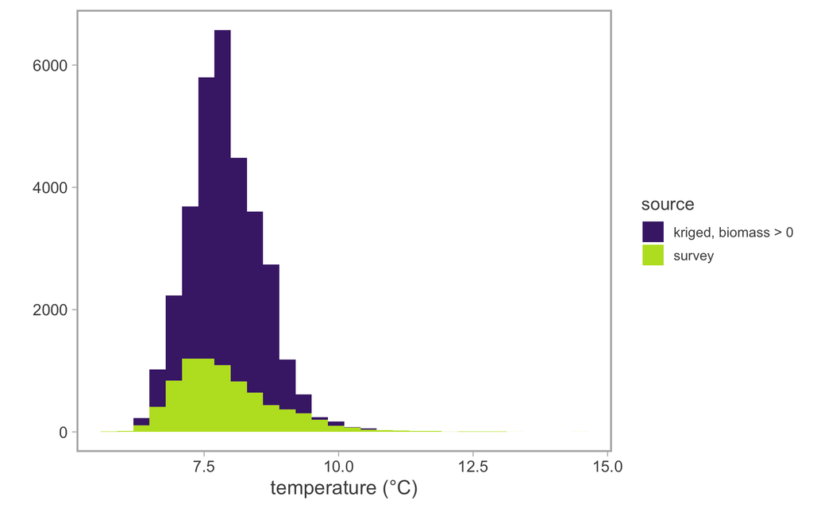

*Yearly temperature at 100m for the survey area from 1995-2019 and for the gridded, kriged temperatures where hake biomass was estimated to be greater than 0.*

For a full implementation of CEATTLE, temperature data back to 1980 are needed to produce the consumption estimates. The [Regional Ocean Modeling System (ROMS)](https://www.myroms.org/) includes temperature estimates for the California Current for 1980-2019. Even when filtered to represent only the summer months, the yearly means for the ROMS output for 1995-2019 are much lower than the kriged data and the survey temperatures.

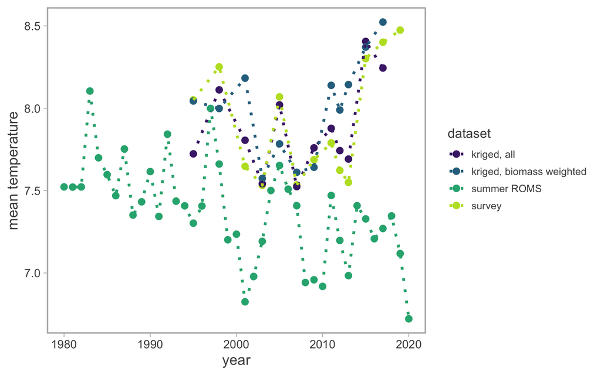

*Yearly mean kriged temperatures overall, mean kriged temperatures weighted by hake biomass estimate for that grid, mean survey temperatures, and mean ROMS output for the summer months.*

Whether this difference reflects sampling bias or a true difference in estimation, and whether the deviance (within approximately 1.5°C) is enough to affect the outcomes of the model, are possible areas of exploration.

### Bioenergetics

The climate and trophic linkeages in CEATTLE are driven by two consumption functions - allometric mass and temperature-dependent consumption. The estimates for allometric mass for hake come from [Francis (1983)](https://cdnsciencepub.com/doi/10.1139/f83-223), with the relationship $C = CA * weight ^ {CB}$, where $CA$ is the consumption by a 1g fish at optimal temperature and $CB$ is the allometric scaling coefficient of consumption (per gram of predator) with predator weight. The estimates for $CA$ and $CB$ from [Francis (1983)](https://cdnsciencepub.com/doi/10.1139/f83-223) (0.167; -0.460) are very similar to those used by Adams et al. (in prep) for pollock. [Francis (1983)](https://cdnsciencepub.com/doi/10.1139/f83-223) also notes that the estimated value of $CA = 0.167$ resulted from modeling the feeding-growing season, equated to 1.1-0.7% body weight consumed per day. [Francis (1983)](https://cdnsciencepub.com/doi/10.1139/f83-223) notes that annual values would be approximately half this: 0.4-0.5% body weight per day, corresponding to $CA = 0.0835$.

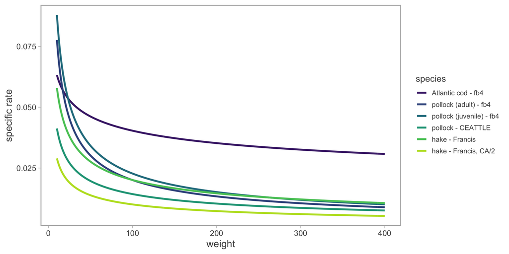

*Allometric mass function using values for Atlantic cod and juvenile and adult pollock from Fish Bioenergetics 4, pollock in CEATTLE from Adams et al. (2022), and the values for hake from Francis (1983).*

Following [Holsman et al. (2016)](https://www.sciencedirect.com/science/article/pii/S0967064515002751?casa_token=p_GOXy4_a04AAAAA:0k6yddGRTvDMkO-8gjvmltiZAkt-oS7BF_vCCq9q_hgldetgGY6HHiJB3LDCvxqTe9mErK68gSg) and Adams et al. (in prep), hake consumption is modeled as dependent on temperature and body size, following [Kitchell et al. (1977)](https://cdnsciencepub.com/doi/abs/10.1139/f77-258?journalCode=jfrbc). Temperature-dependent consumption is summarized as:

$F(T) = V^X * e^{X(1 - V)}$

where:

$V = (TCM - T) / (TCM - TCO)$

$X - (Z^2 * (1 + (1 + 40 / Y)^{0.5})^2) / 400$

$Z = ln(CQ) * (TCM - TCO)$

$Y = ln(CQ) * (TCM - TCO + 2)$

$T$ is the temperature experienced by the hake and $TCM$ and $TCO$ are the maximum and optimal temperatures. $CQ$ represents the effect of temperature on consumption rate and would typically be derived from laboratory weight- and temperature-specific consumption experiments, which are lacking for Pacific hake. For comparison, in Holsman et al. (2016), the CEATTLE model for pollock, Pacific cod, and arrowtooth flounder relies on laboratory-derived bioenergetics parameters [(Holsman and Aydin 2005)](https://www.int-res.com/articles/meps2015/521/m521p217.pdf), which are available for these or related species. Without such studies for hake or other Merluccidae, we assume $CQ = 2.5$, slightly lower than for pollock and near the value for other species in Gadiformes, as summarized by [DesLauriers et al. (2017) in the Fish Bioenergetics 4.0 R package](http://fishbioenergetics.org/). Our value for CQ is also consistent with the global metanalyses of the related $Q_{10}$ parameter [(Dell et al. 2011)](https://www.pnas.org/content/108/26/10591).

$TCM$ and $TCO$, the maximum and optimal temperatures, have not been empirically derived from laboratory studies on hake, but have been approximated based on occurrence of Pacific hake, matched to the kriged, gridded temperatures from the acoustic survey ([Malick et al. 2020](https://www.int-res.com/abstracts/meps/v639/p185-197/)). Using this estimate of temperature when hake were present resulted in the same median temperature (8°C) and a lower maximum temperature (10.5°C, compared to 14.5°C).

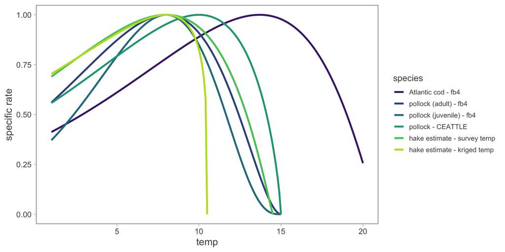

*Temperature-dependent consumption rate function using values for Atlantic cod and pollock from Fish Bioenergetics 4, pollock in CEATTLE from Adams et al. (2022), and the estimates for hake. Optimal and maximum temperatures for hake are modelled for the entire acoustic survey area and for kriged, grided temperatures where hake were present.*

### Predation (diet)

This implementation of the CEATTLE model focuses on hake cannibalism, assumed across the literature to form a significant portion of the Pacific hake diet [(Ressler et al. 2007)](https://www.google.com/books/edition/Marine_Fisheries_Review/Fh2EDlfePrcC?hl=en&gbpv=1). Stomachs gathered from the hake survey, however, do not show a high rate of cannibalism. The dataset includes only 16 instances of hake cannibalism out of 3995 hake stomachs collected from 2005-2019, a rate of 0.4%.

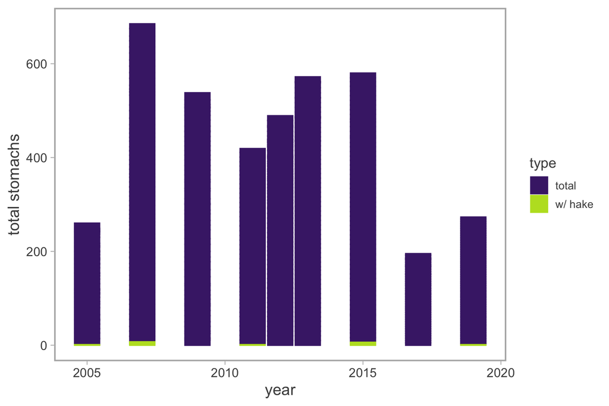

*Pacific hake stomachs collected during the hake survey from 2005-2019, overall and with hake as a prey item.*

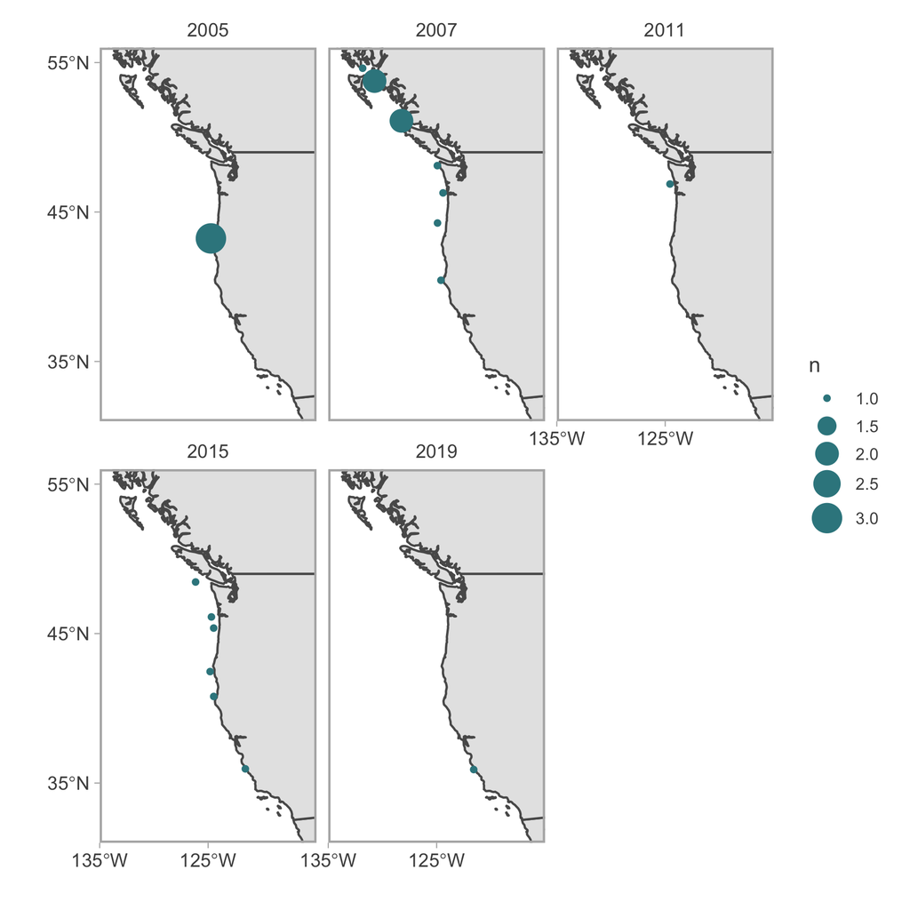

*Locations of cannibalized hake for each year where cannibalism was detected.*

Looking at other sources of hake diet data, the cannibalism rate varies broadly from no cannibalism detected to over 80% of hake stomachs including hake as prey. These data are largely from adult hake. The one study that included juvenile hake found a cannibalism rate of 4.44%. The variability in cannibalism may be due to changes in the spatial overlap between adults and juveniles (as intra-cohort cannibalism is not generally detected - supported by the size disparity in predator and prey hake in the acoustic dataset) [(Ressler et al. 2007)](https://www.google.com/books/edition/Marine_Fisheries_Review/Fh2EDlfePrcC?hl=en&gbpv=1).

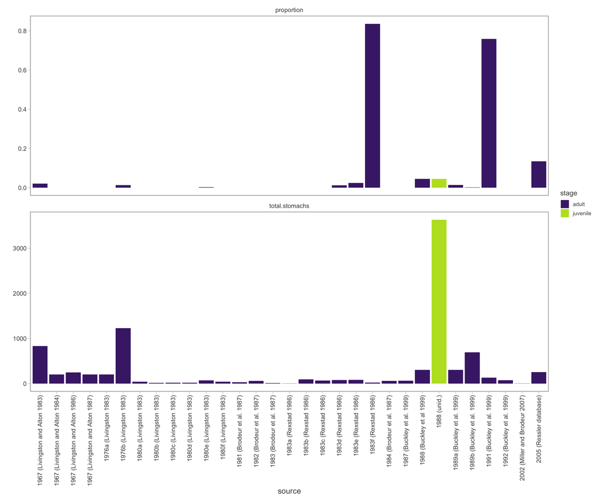

*Rates of cannibalism from additional sources of diet data for majority adults, with one dataset for juvenile hake.*

While the occurrence of hake cannibalism is extremely variable, when they are present in the stomach, they constitute a large percentage by weight. A dataset from the Southwest Fisheries Science Center (SWFSC), which extends back to 1980, indicates some hake cannibalism, with hake appearing in the top 10 prey items by occurrence, dwarfed by euphausiids. In contrast, by weight hake represent by far the largest (or heaviest) component of the diet.

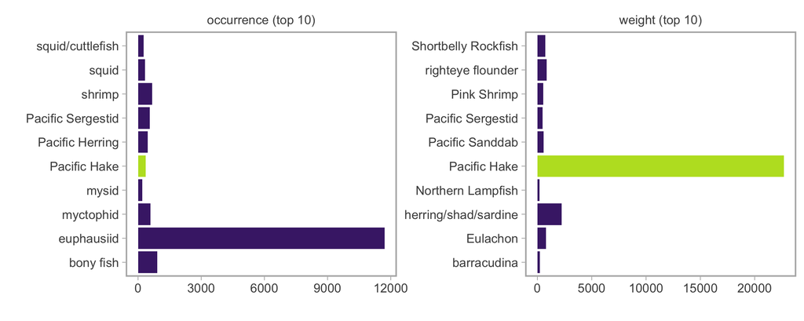

*Top 10 hake prey items by occurrence and weight.*

While a large proportion of the hake diet appears to be cannibalism on occassion, occurrence is highly variable across years and largely reflects the intensity of sampling, as with a large sampling effort in the 1990s came an increase in the amount of cannibalsim detected.

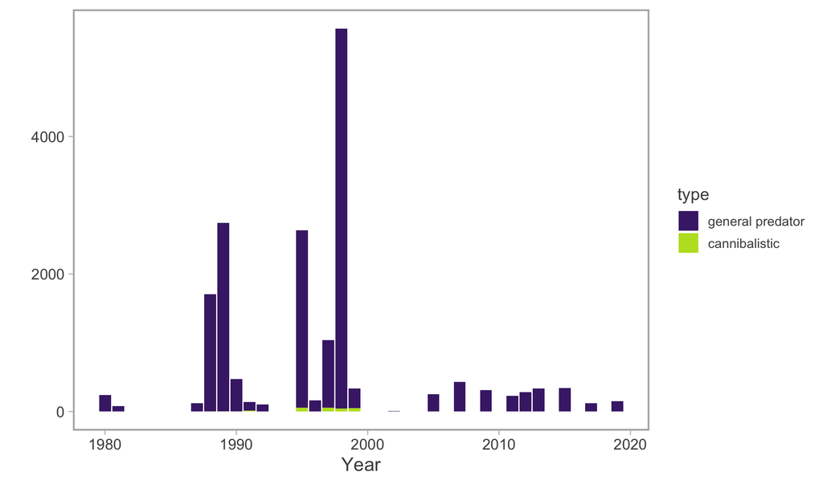

*Numbers of hake predators, general and instances of cannibalism, across the dataset.*

This high degree of variability may have many causes as hake are opportunistic predators. Perhaps the surveyed time and location did not intercept instances of overlap between small and large hake. Within this dataset, sampling was focused on the summer months, but with a higher relative proportion of hake cannibalism detected in the autumn (October and November).

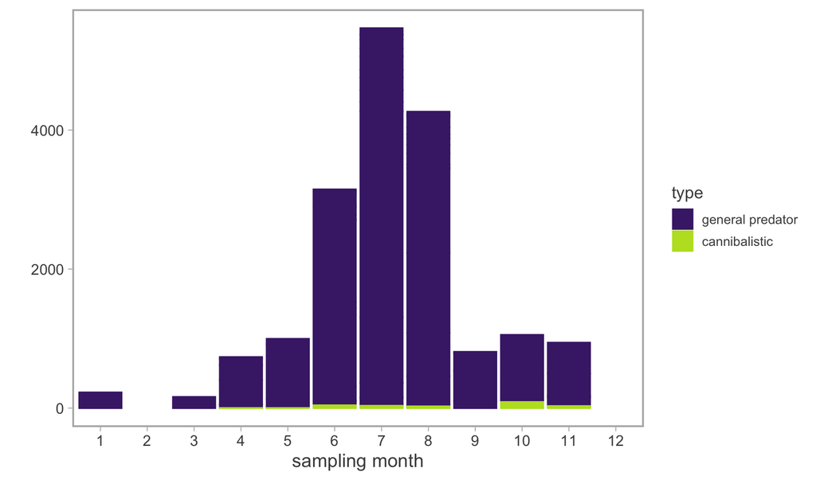

*Total hake predators, general and instances of cannibalism, by month of sampling across all years.*

The SWFSC dataset covers the Canadian coast up to 55°N to the Baja coast at 32°N, with relatively even sampling intensity for all years (1980-2019) combined.

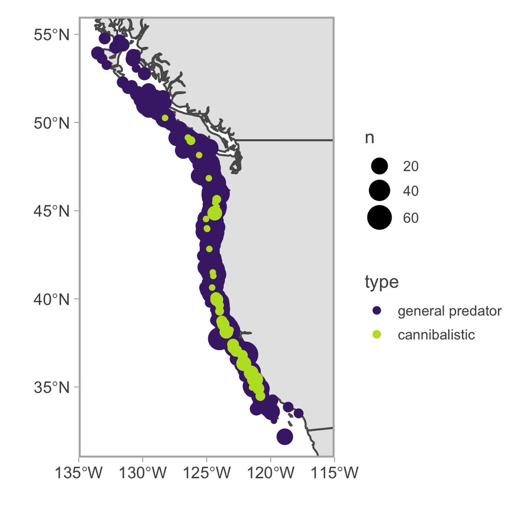

*All sampling locations of hake predators, general and instances of cannibalism, across all years.*

There were slightly more instances of cannibalism detected below 40°, which is somewhat aligned with the more intense southern sampling in 1991 and 1999. In 1991 the sampling of hake occurred in November and in 1999, the bulk of the sampling of hake occurred in October, with a relatively high proportion of hake cannibalism detected.

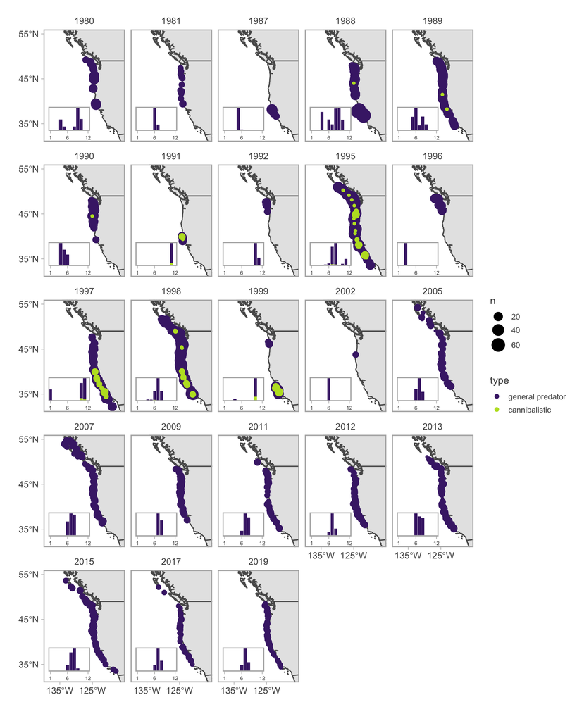

*Sampling location and month of hake predators, general and instances of cannibalism, per year.*